# Breve análise do PIB ótica da demanda

Ludmila Giuli Pedroso

20/02/2022

# Introdução

A análise de conjuntura envolve não apenas a visualização de dados de um economia em um período de tempo. Compreender o que os dados retratam é tão significativo quanto saber organizá-los e apresentá-los corretamente. Sob tal aspecto, pretende-se abordar de maneira breve uma análise do Produto Interno Bruto (PIB), tomando a ótica da demanda, lançando luz sobre a crise econômica brasileira ter se aprofundado em período anterior a crise sanitária de Covid-19. De modo que o PIB definido pelos componentes da demanda são determinados por: $PIB = Consumo+Governo+FBCF+Exportações-Importações$ Para acompanhar tal análise, faz-se uso de três pacotes no R: **sidrar** - que capta via API dados do site [SIDRA IBGE](https://sidra.ibge.gov.br/home/cnt/brasil) - e pacote **seasonal** - que permite dessazonalizar os dados segundo o protocolo X-13 ARIMA-SEATS desenvolvido pelo Census Bureau Norte Americano. Por fim, o pacote **highcharter** que fornece gráficos interativos em HTML, no qual o usuário pode filtrar as séries plotadas, avaliar o valor no ponto do cursor e seu tamanho é ajustado de maneira dinâmica para o tamanho da janela utilizada no navegador.

## Carregando os pacotes

```r
library(sidrar)
library(seasonal)
library(highcharter)
```

## Coletando os dados via API

Após o carregamento dos pacotes, no site [SIDRA](https://sidra.ibge.gov.br/home/cnt/brasil) seleciona-se a aba CNT e utiliza-se a tabela 1620, que apresneta a série encadeada do PIB e seus componentes trimestralmente com ano base em 1995. Seleciona-se as opções de **Despesa de consumo das famílias**, **Despesa de consumo da administração pública**, **Formação Bruta do Capital Fixo (FBCF)**, **Exportações de Bens e Serviços** e **Importações de Bens e Serviços**, que somados resultam no **PIB a preços de mercado**, que também deve ser selecionado. Seleciona-se todo o período de trimestres e o nível territorial **Brasil**. Aperta-se o botão **Links de Compartilhar**, no canto inferior direito. Abre-se uma nova janela e seleciona-se o campo **Parâmetros para API** a partir de **/t…**. No R, utiliza-se a função **get_sidra** onde será utilizado o API copiado no site. Renomeamos as colunas para facilitar a organização do data frame. Conforme a seguir:

```r
tabela <- get_sidra(api = '/t/1620/n1/all/v/all/p/all/c11255/90707,93404,93405,93406,93407,93408/d/v583%202')

series <- c(90707,93404,93405,93406,93407,93408)

names <- c('PIB', 'Consumo', 'Governo', 'FBCF', 'Exportações', 'Importações')

pib <- matrix(NA, ncol=length(series),
              nrow=nrow(tabela)/length(series))

for(i in 1:length(series)){

  pib[,i] <- tabela$Valor[tabela$`Setores e subsetores (Código)`
                          ==series[i]]
  pib <- ts(pib, start=c(1996,01), freq=4)
  colnames(pib) <- names

}

tail(pib)
```

```
##           PIB Consumo Governo   FBCF Exportações Importações
##  [98,] 151.61  157.88  136.44 128.71      314.10      207.23
##  [99,] 167.19  173.85  140.52 150.53      315.48      208.67
## [100,] 170.10  185.96  146.34 169.80      298.21      248.34
## [101,] 169.04  174.97  136.45 178.79      284.80      266.69
## [102,] 170.26  174.54  144.33 171.29      358.84      249.33
## [103,] 173.88  181.21  145.38 178.76      328.03      251.58
```

Observa-se que tem-se um data frame com 103 linhas que correspondem a cada trimestre.

## Gráfico sem ajuste

Para uma breve visualização de cada componente da demanda do PIB, pode-se plotar um gráfico, conforme a orientação a seguir:

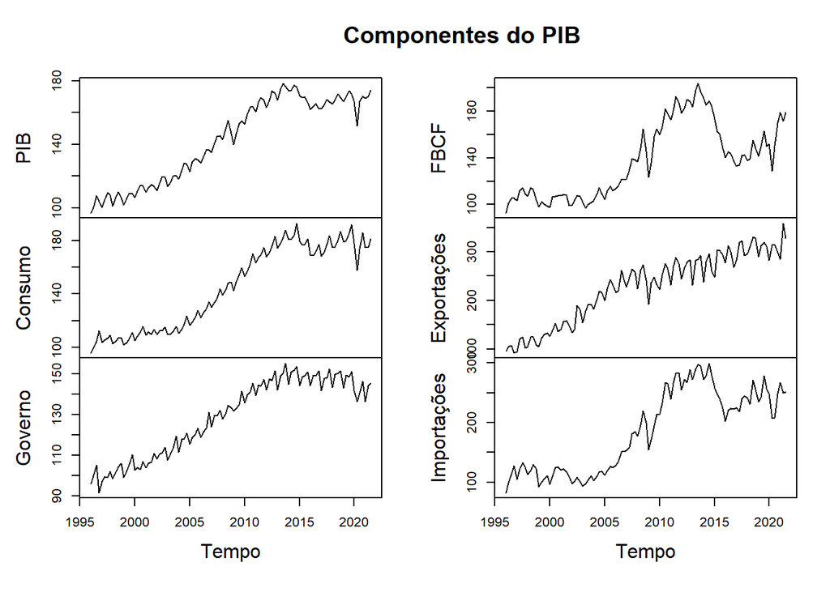

```r
plot(pib, main = "Componentes do PIB", xlab = "Tempo")
```

Na figura acima foi possível identificar visualmente que a série tem duas características: a) ela está em número índice; b) ela possui carga sazonal;

Em vista disso, iremos tratar a série para sazonalidade e, posteriomente, transformar em taxa de crescimento e acumulá-las a partir de um mesmo ano base. O intuito do segundo exercício é torná-las comparáveis partindo de um ano base escolhido.

Para dessazonalizar, utiliza-se a função **seas()** do pacote **seasonal** na série desejada.

```r
### Dessazonalização do PIB Total
Seas_pib <- seas(pib[,1])

### Dessazonalização das Rubricas de Demanda
Seas_con  <- seas(pib[,2])
Seas_gov  <- seas(pib[,3])
Seas_fbcf <- seas(pib[,4])
Seas_exp  <- seas(pib[,5])
Seas_imp  <- seas(pib[,6])
```

## Componentes do PIB dessazonalizados

Na parte subsequente do bloco, extraí-se a série ajustada (dessazonalizada) e uni-se lado a lado cada série temporal tratada. Daí, transforma-se em taxa de crescimento. Em termos de linguagem R, aparece através do uso da função **cumprod()**. Todavia, o seu uso remove a classe **ts()**. Por essa razão, precisamos declarar novamente como **ts()**:

```r
### Junção dos Componentes do PIB
Pib_Des  <- Seas_pib$data[,3]
Con_Des  <- Seas_con$data[,3]
Gov_Des  <- Seas_gov$data[,3]
FBCF_Des <- Seas_fbcf$data[,3]
Exp_Des  <- Seas_exp$data[,3]
Imp_Des  <- Seas_imp$data[,3]

PIB_D <- cbind(Pib_Des,Con_Des,Gov_Des,FBCF_Des,Exp_Des,Imp_Des)

TC_PIB_A  <- (PIB_D/lag(PIB_D,-1)-1)

Pib_ac    <- ts(cumprod(TC_PIB_A[,1]+1)-1, start =c(1996,2), frequency = 4)
Con_ac    <- ts(cumprod(TC_PIB_A[,2]+1)-1, start =c(1996,2), frequency = 4)
Gov_ac    <- ts(cumprod(TC_PIB_A[,3]+1)-1, start =c(1996,2), frequency = 4)
Fbcf_ac   <- ts(cumprod(TC_PIB_A[,4]+1)-1, start =c(1996,2), frequency = 4)
Exp_ac    <- ts(cumprod(TC_PIB_A[,5]+1)-1, start =c(1996,2), frequency = 4)
Imp_ac    <- ts(cumprod(TC_PIB_A[,6]+1)-1, start =c(1996,2), frequency = 4)
```

## Gráfico do PIB e seus componentes

Por fim, pode-se plotar um gráfico de taxa de crescimento acumulado para facilitar a análise dos componentes do PIB pela ótica da demanda na série dessazonalizada, seguindo o código:

```r
hchart(Pib_ac, color = "black", name = "PIB - % Acumulado") %>%
  hc_add_series(Con_ac, color = "orange", name = "Consumo - % Acumulado") %>%
  hc_add_series(Gov_ac, color = "purple",  name = "Consumo do Governo - % Acumulado") %>%
  hc_add_series(Fbcf_ac, color = "magenta",  name = "FBCF - % Acumulado") %>%
  hc_add_series(Exp_ac-Imp_ac, color = "red",  name = "Exportações Líquidas - % Acumulado") %>%
  hc_title(text = "Taxa de Crescimento Acumulado dos Componentes da Oferta do PIB", margin = 10,
           style = list(fontSize= "14px")) %>%
  hc_subtitle(text = "Dados Trimestrais: 1T1996 a 2T2019") %>%
  hc_xAxis(plotBands = list(
    list(
      label = list(text = "FHC 1"),
      from = datetime_to_timestamp(as.Date('1996-01-01', tz = 'UTC')),
      to = datetime_to_timestamp(as.Date('1998-12-31', tz = 'UTC'))),
    list(
      label = list(text = "FHC 2"),
      from = datetime_to_timestamp(as.Date('1999-01-01', tz = 'UTC')),
      to = datetime_to_timestamp(as.Date('2002-12-31', tz = 'UTC'))),
    list(
      label = list(text = "Lula 1"),
      from = datetime_to_timestamp(as.Date('2003-01-01', tz = 'UTC')),
      to = datetime_to_timestamp(as.Date('2006-12-31', tz = 'UTC'))),
    list(
      label = list(text = "Lula 2"),
      from = datetime_to_timestamp(as.Date('2007-01-01', tz = 'UTC')),
      to = datetime_to_timestamp(as.Date('2010-12-31', tz = 'UTC'))),
    list(
      label = list(text = "Dilma 1"),
      from = datetime_to_timestamp(as.Date('2011-01-01', tz = 'UTC')),
      to = datetime_to_timestamp(as.Date('2014-12-31', tz = 'UTC'))),
    list(
      label = list(text = "Dilma 2"),
      from = datetime_to_timestamp(as.Date('2015-01-01', tz = 'UTC')),
      to = datetime_to_timestamp(as.Date('2016-08-31', tz = 'UTC'))),
    list(
      label = list(text = "Temer"),
      from = datetime_to_timestamp(as.Date('2016-09-01', tz = 'UTC')),
      to = datetime_to_timestamp(as.Date('2018-12-31', tz = 'UTC'))),
    list(
      label = list(text = "Bolsonaro"),
      from = datetime_to_timestamp(as.Date('2019-01-01', tz = 'UTC')),
      to = datetime_to_timestamp(as.Date('2021-07-31', tz = 'UTC')))
  ))
```

[interactive chart not shown]

## Considerações

O que se observa com a figura do gráfico acima é que as exportações brasileiras líquidas - já subtraindo o valor das importações - tiveram uma queda brusca após o período de *boom de commodities* durante o Governo de Lula 2, um aumento e depois estagnação da FBCF no Governo de Dilma 1 mas não devido a uma melhoria significativa do parque industrial brasileiro. O Consumo das famílias tem uma trajetória muito semelhante a trajetória do PIB, tendo em vista que as políticas de incentivo ao consumo ganham força durante os governos do PT e impactam cerca de 65% do valor total do PIB no país. De maneira que qualquer alteração neste componente, seu efeito multiplicador no PIB é considerável. E o Consumo do Governo manteve-se estagnado desde a mudança de postura política no governo Dilma 2. Logo, o processo de crise econômica brasileira é anterior a crise pandêmica Covid-19. Considerando-se que a balança comercial - exportações menos importações - detém momentos de crise significativo e a pauta exportadora é composta quase na sua totalidade por produtos agropecuários, o consumo não é incorporado de modo sustentado. De maneira que a recuperação da crise agravada pela crise pandêmica tem se tornado mais longa.

## Referência

Este trabalho tem como referência [Análise Qualitativa dos Dados do PIB - Sidra](https://rpubs.com/julio_costa/PIB_SIDRA).